# ROADMAP: Simulated Trial Behaviour (sim07)

Published

October 27, 2026

# About this report

This report summarises the earlier **sim07** simulations in the same format as the sim09 report, so that the operating characteristics of the two approaches can be compared side by side. Only the high-level summaries across scenarios are reproduced here; scenario-by-scenario detail and the appendix are not yet included.

ROADMAP is an adaptive platform trial in prosthetic joint infection. It has four domains and is designed to stop recruiting into a domain when the accumulated evidence is strong enough but continue recruitment into the other domains. Loosely, the four questions are:

- **D1 - Surgical strategy:** is revision surgery (removing and replacing the joint) better than DAIR (debridement and implant retention) for patients with a late-acute infection?
- **D2 - Antibiotic duration:** among patients having a one-stage revision (r1), is a shorter (6-week) course of antibiotics non-inferior to a 12-week course?
- **D3 - Extended prophylaxis:** among patients having a two-stage revision (r2), does an extra 12 weeks of preventive antibiotics improve outcomes compared with none?
- **D4 - Rifampicin:** does adding rifampicin to the antibiotic regimen improve outcomes?

At each interim analysis, the trial looks at the data collected to date for each of these four questions and asks whether the evidence is strong enough to draw a conclusion. If so, the simulation stops randomising patients to that question and adopts the better (or, for d2, non-inferior) option going forward. Futility stopping is also implemented.

This report covers 7 scenario(s):

- RD = 0 in all domains +silo specific d1
- RD = 0.12: surgical revision (one and two-stage) +silo specific d1
- RD = 0.12: surgical revision (one-stage only) +silo specific d1
- RD = 0.12: abx duration 6wk effect +silo specific d1
- RD = 0.12: ext-proph 12wk effect +silo specific d1
- RD = -0.05: abx duration 6wk effect +silo specific d1
- RD = 0.12: abx choice rif effect +silo specific d1

The results data are those stored in **sim07-14** and have **2500** iterations per scenario.

# How to read the results

For each scenario, we report:

1. **Chance of reaching each decision, by interim** - across many simulated trials, what proportion concluded superiority / non-inferiority / futility for each domain, by each interim analysis.
2. **Typical patient numbers** - how many patients are typically enrolled, and how many directly inform each domain’s own comparison, by the time a decision is reached.

These are defined exactly as in the sim09 report so the two can be read side by side.

# Simulation configuration

The table(s) below describe parts of the design that are the same across every scenario in this report; only the assumed true effects differ.

sim07 has three silos. Only the late-acute silo is randomised to DAIR versus revision; early and chronic infections receive whichever surgical strategy their clinician deems appropriate. Unlike sim09, there is no separate late-acute non-randomised group: all late-acute patients are assumed to enter the D1 randomisation. The type of revision (one-stage vs two-stage) is set by the surgeon’s preference, which is elicited at baseline before the randomisation is revealed.

## Analysis model

The sim07 analysis model is a single logistic regression with an intercept, silo effects, a preference effect, a 3x3 set of silo-by-surgery (d1) effects, and vector terms for d2, d3 and d4, where each includes a level for patients who did not enter the domain. D2 terms enter only for one-stage patients and D3 terms only for two-stage patients. The silo main effects and the silo-by-surgery terms overlap, so those parameters are separated only by their priors; the treatment contrasts are unaffected because they depend only on the sums.

Treatment effects are obtained by g-computation inside Stan, with standardisation weights drawn from a Bayesian bootstrap (Dirichlet weights on the observed covariate patterns) at each posterior draw.

- **D1** compares DAIR with revision in the late-acute silo. Revision is taken as one-stage for patients whose surgeon preferred one-stage and two-stage for those who preferred two-stage, with the downstream D2/D3 treatment held at the ‘not entered’ level. The two are combined in the observed preference proportions.
- **D2 and D3** standardise over all one-stage (respectively two-stage) patients across silos, including those who did not enter the domain.
- **D4** standardises over patients randomised within D4.

## Decision rules

For each domain, a decision is reached once the trial is sufficiently confident that the true effect exceeds (or, for futility, falls short of) a pre-specified margin. In sim07 each rule is evaluated and locked separately, so a domain can trigger a second rule after its first. Only the **first** decision changed allocation in sim07, so only the first is counted here, matching sim09. Where two rules for a domain first trigger at the same interim, superiority (or non-inferiority) takes precedence, as in the sim07 allocation logic.

Decision rules by domain

| Rule | Effect margin (delta) | Confidence required |
| --- | --- | --- |
| D1: Surgical strategy |  |  |
| Superiority | +0.000 | 95.0% |
| Futility | +0.050 | 30.0% |
| D2: Antibiotic duration |  |  |
| Non-inferiority | -0.050 | 95.0% |
| Futility | +0.000 | 10.0% |
| D3: Extended prophylaxis |  |  |
| Superiority | +0.000 | 95.0% |
| Futility | +0.050 | 30.0% |
| D4: Rifampicin |  |  |
| Superiority | +0.000 | 99.0% |
| Futility | +0.050 | 30.0% |

# Overall summary across scenarios

This section puts all scenarios side by side, so the behaviour of each comparison can be seen across the range of assumed truths.

## Assumed true effects

The true effects are the standardised risk differences implied by the sim07 data-generating process for the sim07 estimands, evaluated in the design population (all domains open, before any adaptation changes allocation). They are shown in percentage points. Because the sim07 and sim09 estimands differ (most notably for D1, where sim07 holds the downstream D2/D3 treatment at the ‘not entered’ level), a scenario with the same label can imply a different true effect in the two reports.

Assumed true risk difference (pp) by domain

| Scenario | D1: Surgical strategy | D2: Antibiotic duration | D3: Extended prophylaxis | D4: Rifampicin |
| --- | --- | --- | --- | --- |
| RD = 0 in all domains +silo specific d1 | 0.00 | 0.00 | 0.00 | 0.00 |
| RD = 0.12: surgical revision (one and two-stage) +silo specific d1 | 12.12 | 0.00 | 0.00 | 0.00 |
| RD = 0.12: surgical revision (one-stage only) +silo specific d1 | 2.68 | 0.00 | 0.00 | 0.00 |
| RD = 0.12: abx duration 6wk effect +silo specific d1 | 0.00 | 12.09 | 0.00 | 0.00 |
| RD = 0.12: ext-proph 12wk effect +silo specific d1 | 0.00 | 0.00 | 11.99 | 0.00 |
| RD = -0.05: abx duration 6wk effect +silo specific d1 | 0.00 | −5.03 | 0.00 | 0.00 |
| RD = 0.12: abx choice rif effect +silo specific d1 | 0.00 | 0.00 | 0.00 | 12.11 |

## Chance of each decision

For each domain, the first decision reached locks that domain, so within a domain the possible decisions are mutually exclusive. The remainder (100% less the decision columns) is the chance that the domain is still open at the final interim. The first table gives the position at the final interim (interim 5, cumulative enrolment of 2500). The domain tabs that follow show how those chances build up over the interim analyses (cumulative enrolment at interims 1 to 5 is 500, 1000, 1500, 2000, 2500). The true effect for each scenario is on the risk-difference scale in percentage points (pp).

Chance of each decision by interim 5

| Scenario | D1: Surgical strategy Superiority | D1: Surgical strategy Futility | D2: Antibiotic duration Non-inferiority | D2: Antibiotic duration Futility | D3: Extended prophylaxis Superiority | D3: Extended prophylaxis Futility | D4: Rifampicin Superiority | D4: Rifampicin Futility |
| --- | --- | --- | --- | --- | --- | --- | --- | --- |
| RD = 0 in all domains +silo specific d1 | 8% | 85% | 27% | 21% | 12% | 81% | 2% | 96% |
| RD = 0.12: surgical revision (one and two-stage) +silo specific d1 | 85% | 10% | 38% | 23% | 11% | 87% | 3% | 95% |
| RD = 0.12: surgical revision (one-stage only) +silo specific d1 | 19% | 71% | 29% | 21% | 10% | 84% | 2% | 97% |
| RD = 0.12: abx duration 6wk effect +silo specific d1 | 9% | 84% | 83% | 2% | 11% | 81% | 3% | 96% |
| RD = 0.12: ext-proph 12wk effect +silo specific d1 | 9% | 84% | 29% | 21% | 83% | 12% | 3% | 95% |
| RD = -0.05: abx duration 6wk effect +silo specific d1 | 8% | 85% | 12% | 41% | 11% | 81% | 3% | 95% |
| RD = 0.12: abx choice rif effect +silo specific d1 | 7% | 86% | 30% | 21% | 11% | 83% | 96% | 4% |

**D1: Surgical strategy**

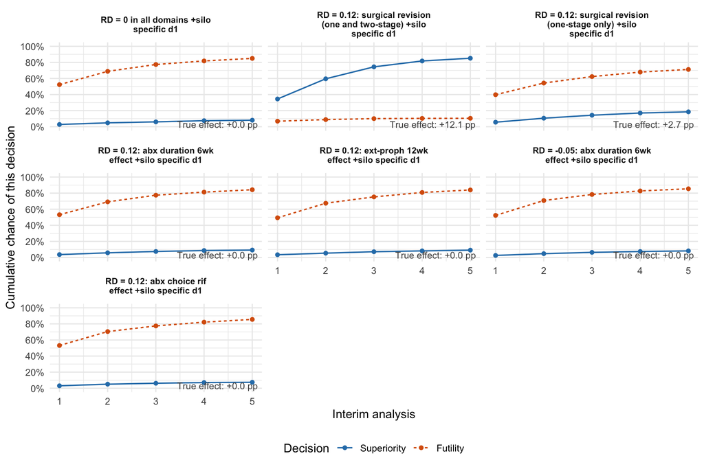

| Decision | Interim 1 | Interim 2 | Interim 3 | Interim 4 | Interim 5 |
| --- | --- | --- | --- | --- | --- |
| RD = 0 in all domains +silo specific d1 (true effect +0.0 pp) |  |  |  |  |  |
| Superiority | 3% | 5% | 6% | 8% | 8% |
| Futility | 52% | 69% | 77% | 82% | 85% |
| RD = 0.12: surgical revision (one and two-stage) +silo specific d1 (true effect +12.1 pp) |  |  |  |  |  |
| Superiority | 34% | 60% | 74% | 82% | 85% |
| Futility | 7% | 9% | 10% | 10% | 10% |
| RD = 0.12: surgical revision (one-stage only) +silo specific d1 (true effect +2.7 pp) |  |  |  |  |  |
| Superiority | 6% | 11% | 14% | 17% | 19% |
| Futility | 40% | 54% | 62% | 68% | 71% |
| RD = 0.12: abx duration 6wk effect +silo specific d1 (true effect +0.0 pp) |  |  |  |  |  |
| Superiority | 4% | 6% | 7% | 9% | 9% |
| Futility | 53% | 69% | 77% | 81% | 84% |
| RD = 0.12: ext-proph 12wk effect +silo specific d1 (true effect +0.0 pp) |  |  |  |  |  |
| Superiority | 3% | 5% | 7% | 8% | 9% |
| Futility | 49% | 67% | 75% | 81% | 84% |
| RD = -0.05: abx duration 6wk effect +silo specific d1 (true effect +0.0 pp) |  |  |  |  |  |
| Superiority | 3% | 5% | 6% | 7% | 8% |
| Futility | 52% | 71% | 78% | 83% | 85% |
| RD = 0.12: abx choice rif effect +silo specific d1 (true effect +0.0 pp) |  |  |  |  |  |
| Superiority | 3% | 5% | 6% | 7% | 7% |
| Futility | 53% | 70% | 77% | 82% | 86% |

**D2: Antibiotic duration**

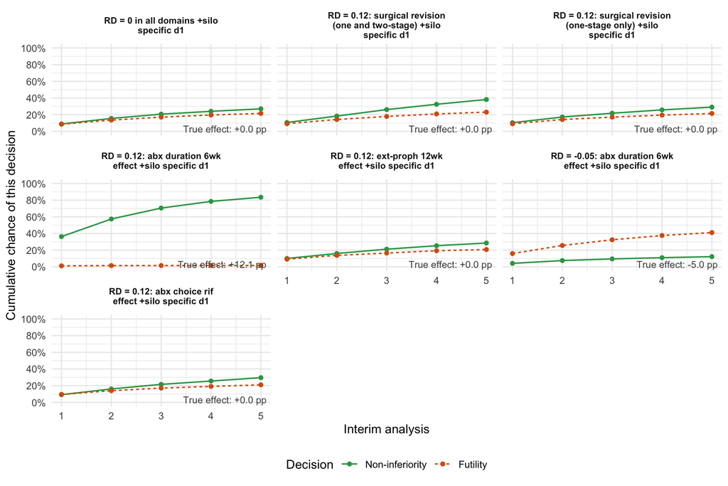

| Decision | Interim 1 | Interim 2 | Interim 3 | Interim 4 | Interim 5 |
| --- | --- | --- | --- | --- | --- |
| RD = 0 in all domains +silo specific d1 (true effect +0.0 pp) |  |  |  |  |  |
| Non-inferiority | 9% | 15% | 21% | 24% | 27% |
| Futility | 9% | 13% | 17% | 20% | 21% |
| RD = 0.12: surgical revision (one and two-stage) +silo specific d1 (true effect +0.0 pp) |  |  |  |  |  |
| Non-inferiority | 11% | 18% | 26% | 32% | 38% |
| Futility | 9% | 14% | 18% | 21% | 23% |
| RD = 0.12: surgical revision (one-stage only) +silo specific d1 (true effect +0.0 pp) |  |  |  |  |  |
| Non-inferiority | 10% | 17% | 22% | 26% | 29% |
| Futility | 9% | 14% | 17% | 19% | 21% |
| RD = 0.12: abx duration 6wk effect +silo specific d1 (true effect +12.1 pp) |  |  |  |  |  |
| Non-inferiority | 36% | 57% | 70% | 78% | 83% |
| Futility | 1% | 2% | 2% | 2% | 2% |
| RD = 0.12: ext-proph 12wk effect +silo specific d1 (true effect +0.0 pp) |  |  |  |  |  |
| Non-inferiority | 10% | 16% | 21% | 25% | 29% |
| Futility | 9% | 14% | 16% | 19% | 21% |
| RD = -0.05: abx duration 6wk effect +silo specific d1 (true effect -5.0 pp) |  |  |  |  |  |
| Non-inferiority | 4% | 8% | 9% | 11% | 12% |
| Futility | 16% | 26% | 32% | 38% | 41% |
| RD = 0.12: abx choice rif effect +silo specific d1 (true effect +0.0 pp) |  |  |  |  |  |
| Non-inferiority | 9% | 16% | 22% | 26% | 30% |
| Futility | 9% | 14% | 17% | 19% | 21% |

**D3: Extended prophylaxis**

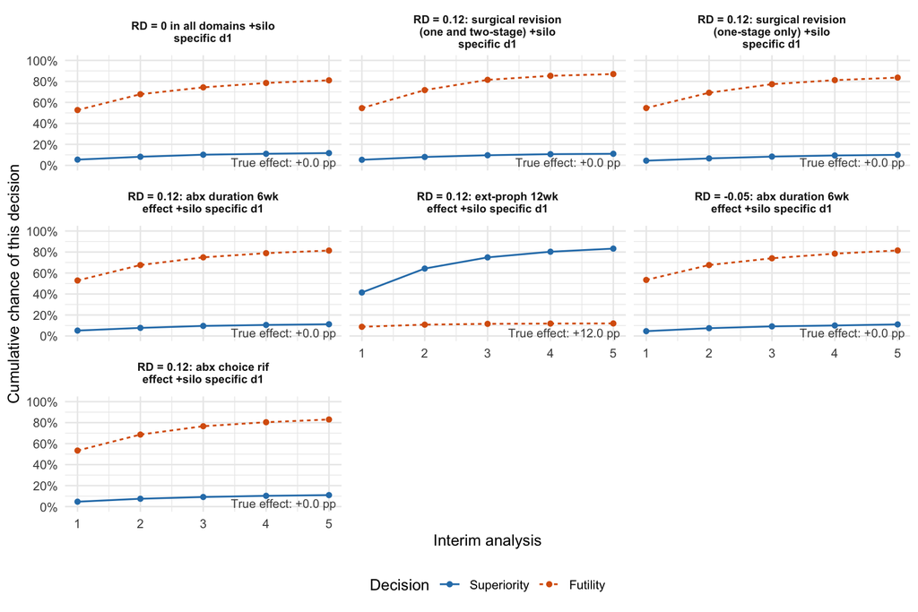

| Decision | Interim 1 | Interim 2 | Interim 3 | Interim 4 | Interim 5 |
| --- | --- | --- | --- | --- | --- |
| RD = 0 in all domains +silo specific d1 (true effect +0.0 pp) |  |  |  |  |  |
| Superiority | 5% | 8% | 10% | 11% | 12% |
| Futility | 53% | 68% | 74% | 79% | 81% |
| RD = 0.12: surgical revision (one and two-stage) +silo specific d1 (true effect +0.0 pp) |  |  |  |  |  |
| Superiority | 5% | 8% | 10% | 11% | 11% |
| Futility | 55% | 72% | 81% | 85% | 87% |
| RD = 0.12: surgical revision (one-stage only) +silo specific d1 (true effect +0.0 pp) |  |  |  |  |  |
| Superiority | 4% | 7% | 8% | 9% | 10% |
| Futility | 55% | 69% | 77% | 81% | 84% |
| RD = 0.12: abx duration 6wk effect +silo specific d1 (true effect +0.0 pp) |  |  |  |  |  |
| Superiority | 5% | 8% | 10% | 11% | 11% |
| Futility | 53% | 68% | 75% | 79% | 81% |
| RD = 0.12: ext-proph 12wk effect +silo specific d1 (true effect +12.0 pp) |  |  |  |  |  |
| Superiority | 41% | 64% | 75% | 80% | 83% |
| Futility | 9% | 11% | 12% | 12% | 12% |
| RD = -0.05: abx duration 6wk effect +silo specific d1 (true effect +0.0 pp) |  |  |  |  |  |
| Superiority | 5% | 7% | 9% | 10% | 11% |
| Futility | 53% | 68% | 74% | 78% | 81% |
| RD = 0.12: abx choice rif effect +silo specific d1 (true effect +0.0 pp) |  |  |  |  |  |
| Superiority | 5% | 7% | 9% | 10% | 11% |
| Futility | 53% | 69% | 77% | 80% | 83% |

**D4: Rifampicin**

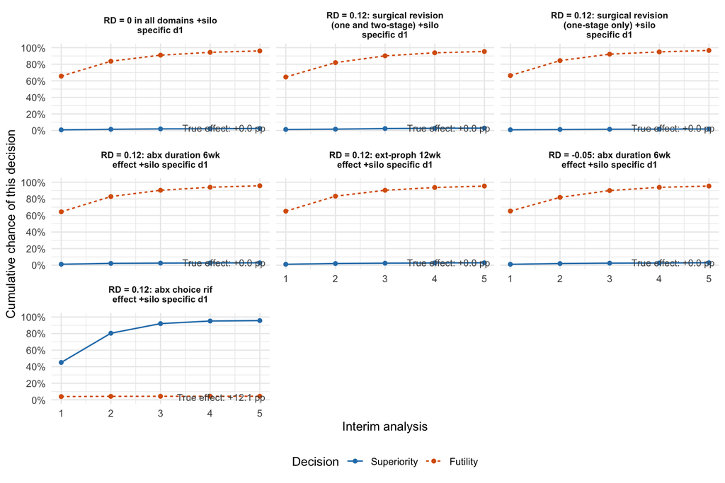

| Decision | Interim 1 | Interim 2 | Interim 3 | Interim 4 | Interim 5 |
| --- | --- | --- | --- | --- | --- |
| RD = 0 in all domains +silo specific d1 (true effect +0.0 pp) |  |  |  |  |  |
| Superiority | 1% | 1% | 2% | 2% | 2% |
| Futility | 66% | 84% | 91% | 94% | 96% |
| RD = 0.12: surgical revision (one and two-stage) +silo specific d1 (true effect +0.0 pp) |  |  |  |  |  |
| Superiority | 1% | 2% | 2% | 3% | 3% |
| Futility | 65% | 82% | 90% | 94% | 95% |
| RD = 0.12: surgical revision (one-stage only) +silo specific d1 (true effect +0.0 pp) |  |  |  |  |  |
| Superiority | 1% | 1% | 2% | 2% | 2% |
| Futility | 66% | 84% | 92% | 95% | 97% |
| RD = 0.12: abx duration 6wk effect +silo specific d1 (true effect +0.0 pp) |  |  |  |  |  |
| Superiority | 1% | 2% | 2% | 3% | 3% |
| Futility | 64% | 83% | 90% | 94% | 96% |
| RD = 0.12: ext-proph 12wk effect +silo specific d1 (true effect +0.0 pp) |  |  |  |  |  |
| Superiority | 1% | 2% | 2% | 3% | 3% |
| Futility | 65% | 83% | 90% | 94% | 95% |
| RD = -0.05: abx duration 6wk effect +silo specific d1 (true effect +0.0 pp) |  |  |  |  |  |
| Superiority | 1% | 2% | 2% | 3% | 3% |
| Futility | 65% | 82% | 90% | 94% | 95% |
| RD = 0.12: abx choice rif effect +silo specific d1 (true effect +12.1 pp) |  |  |  |  |  |
| Superiority | 45% | 80% | 92% | 95% | 96% |
| Futility | 4% | 4% | 4% | 4% | 4% |

## Enrolment and patients informing each decision

These summaries describe the trials in which a decision was reached, at the interim where each domain’s first decision occurred. They should be read alongside the chance of the decision, because a decision that is rarely reached rests on very few simulated trials.

- **Enrolled at decision** is the total number of patients enrolled in the whole platform by that interim, not only those relevant to the domain. Decisions can only occur at an interim analysis, so this is one of the interim enrolment totals (500, 1000, 1500, 2000, 2500) and the average blends them.
- **Informing the decision** is the number of patients contributing to that domain’s own comparison: D1 uses all patients in the late-acute group (DAIR, 1-stage and 2-stage revision), D2 uses 1-stage revision patients randomised to 12 or 6 weeks, D3 uses 2-stage revision patients randomised to 12 weeks or none, and D4 uses patients randomised to rifampicin or not.
- Ranges are the middle 95% across the simulated trials that reached that decision.

**D1: Surgical strategy**

| Decision | Chance of this decision | Enrolled at decision | Informing the decision | Share of enrolled informing |
| --- | --- | --- | --- | --- |
| RD = 0 in all domains +silo specific d1 |  |  |  |  |
| Superiority | 8% | 1195 (500 to 2500) | 596 (233 to 1248) | 50% |
| Futility | 85% | 850 (500 to 2500) | 425 (229 to 1242) | 50% |
| RD = 0.12: surgical revision (one and two-stage) +silo specific d1 |  |  |  |  |
| Superiority | 85% | 1031 (500 to 2500) | 515 (234 to 1243) | 50% |
| Futility | 10% | 773 (500 to 2000) | 386 (231 to 978) | 50% |
| RD = 0.12: surgical revision (one-stage only) +silo specific d1 |  |  |  |  |
| Superiority | 19% | 1215 (500 to 2500) | 606 (238 to 1249) | 50% |
| Futility | 71% | 925 (500 to 2500) | 463 (231 to 1247) | 50% |
| RD = 0.12: abx duration 6wk effect +silo specific d1 |  |  |  |  |
| Superiority | 9% | 1119 (500 to 2500) | 559 (230 to 1261) | 50% |
| Futility | 84% | 832 (500 to 2500) | 415 (230 to 1233) | 50% |
| RD = 0.12: ext-proph 12wk effect +silo specific d1 |  |  |  |  |
| Superiority | 9% | 1175 (500 to 2500) | 588 (232 to 1256) | 50% |
| Futility | 84% | 875 (500 to 2500) | 437 (230 to 1237) | 50% |
| RD = -0.05: abx duration 6wk effect +silo specific d1 |  |  |  |  |
| Superiority | 8% | 1212 (500 to 2500) | 606 (233 to 1249) | 50% |
| Futility | 85% | 836 (500 to 2500) | 418 (230 to 1229) | 50% |
| RD = 0.12: abx choice rif effect +silo specific d1 |  |  |  |  |
| Superiority | 7% | 1059 (500 to 2500) | 531 (237 to 1254) | 50% |
| Futility | 86% | 845 (500 to 2500) | 422 (231 to 1235) | 50% |

**D2: Antibiotic duration**

| Decision | Chance of this decision | Enrolled at decision | Informing the decision | Share of enrolled informing |
| --- | --- | --- | --- | --- |
| RD = 0 in all domains +silo specific d1 |  |  |  |  |
| Non-inferiority | 27% | 1223 (500 to 2500) | 105 (42 to 261) | 9% |
| Futility | 21% | 1136 (500 to 2500) | 97 (41 to 244) | 9% |
| RD = 0.12: surgical revision (one and two-stage) +silo specific d1 |  |  |  |  |
| Non-inferiority | 38% | 1354 (500 to 2500) | 161 (43 to 362) | 11% |
| Futility | 23% | 1155 (500 to 2500) | 132 (40 to 352) | 11% |
| RD = 0.12: surgical revision (one-stage only) +silo specific d1 |  |  |  |  |
| Non-inferiority | 29% | 1208 (500 to 2500) | 112 (43 to 291) | 10% |
| Futility | 21% | 1105 (500 to 2500) | 99 (39 to 266) | 9% |
| RD = 0.12: abx duration 6wk effect +silo specific d1 |  |  |  |  |
| Non-inferiority | 83% | 1047 (500 to 2500) | 91 (40 to 211) | 9% |
| Futility | 2% | 675 (500 to 1512) | 59 (40 to 110) | 9% |
| RD = 0.12: ext-proph 12wk effect +silo specific d1 |  |  |  |  |
| Non-inferiority | 29% | 1230 (500 to 2500) | 106 (41 to 252) | 9% |
| Futility | 21% | 1084 (500 to 2500) | 96 (42 to 258) | 9% |
| RD = -0.05: abx duration 6wk effect +silo specific d1 |  |  |  |  |
| Non-inferiority | 12% | 1185 (500 to 2500) | 101 (41 to 234) | 9% |
| Futility | 41% | 1143 (500 to 2500) | 98 (42 to 251) | 9% |
| RD = 0.12: abx choice rif effect +silo specific d1 |  |  |  |  |
| Non-inferiority | 30% | 1278 (500 to 2500) | 109 (41 to 258) | 9% |
| Futility | 21% | 1080 (500 to 2500) | 94 (42 to 249) | 9% |

**D3: Extended prophylaxis**

| Decision | Chance of this decision | Enrolled at decision | Informing the decision | Share of enrolled informing |
| --- | --- | --- | --- | --- |
| RD = 0 in all domains +silo specific d1 |  |  |  |  |
| Superiority | 12% | 1012 (500 to 2500) | 239 (125 to 546) | 25% |
| Futility | 81% | 813 (500 to 2500) | 202 (123 to 523) | 26% |
| RD = 0.12: surgical revision (one and two-stage) +silo specific d1 |  |  |  |  |
| Superiority | 11% | 976 (500 to 2500) | 300 (125 to 800) | 30% |
| Futility | 87% | 816 (500 to 2000) | 246 (122 to 755) | 29% |
| RD = 0.12: surgical revision (one-stage only) +silo specific d1 |  |  |  |  |
| Superiority | 10% | 1054 (500 to 2500) | 255 (125 to 580) | 26% |
| Futility | 84% | 811 (500 to 2500) | 210 (122 to 562) | 27% |
| RD = 0.12: abx duration 6wk effect +silo specific d1 |  |  |  |  |
| Superiority | 11% | 1027 (500 to 2500) | 244 (126 to 587) | 25% |
| Futility | 81% | 815 (500 to 2500) | 202 (123 to 499) | 26% |
| RD = 0.12: ext-proph 12wk effect +silo specific d1 |  |  |  |  |
| Superiority | 83% | 933 (500 to 2500) | 225 (125 to 508) | 26% |
| Futility | 12% | 704 (500 to 2000) | 176 (121 to 338) | 27% |
| RD = -0.05: abx duration 6wk effect +silo specific d1 |  |  |  |  |
| Superiority | 11% | 1087 (500 to 2500) | 247 (126 to 499) | 25% |
| Futility | 81% | 822 (500 to 2500) | 198 (123 to 479) | 26% |
| RD = 0.12: abx choice rif effect +silo specific d1 |  |  |  |  |
| Superiority | 11% | 1058 (500 to 2500) | 248 (125 to 584) | 25% |
| Futility | 83% | 819 (500 to 2500) | 201 (123 to 454) | 26% |

**D4: Rifampicin**

| Decision | Chance of this decision | Enrolled at decision | Informing the decision | Share of enrolled informing |
| --- | --- | --- | --- | --- |
| RD = 0 in all domains +silo specific d1 |  |  |  |  |
| Superiority | 2% | 1202 (500 to 2500) | 718 (283 to 1528) | 60% |
| Futility | 96% | 760 (500 to 2000) | 456 (280 to 1216) | 60% |
| RD = 0.12: surgical revision (one and two-stage) +silo specific d1 |  |  |  |  |
| Superiority | 3% | 1118 (500 to 2500) | 670 (283 to 1491) | 60% |
| Futility | 95% | 768 (500 to 2000) | 461 (279 to 1217) | 60% |
| RD = 0.12: surgical revision (one-stage only) +silo specific d1 |  |  |  |  |
| Superiority | 2% | 1043 (500 to 2500) | 631 (280 to 1504) | 60% |
| Futility | 97% | 752 (500 to 2000) | 451 (281 to 1216) | 60% |
| RD = 0.12: abx duration 6wk effect +silo specific d1 |  |  |  |  |
| Superiority | 3% | 1007 (500 to 2500) | 602 (286 to 1491) | 60% |
| Futility | 96% | 769 (500 to 2000) | 462 (282 to 1220) | 60% |
| RD = 0.12: ext-proph 12wk effect +silo specific d1 |  |  |  |  |
| Superiority | 3% | 1076 (500 to 2500) | 646 (281 to 1495) | 60% |
| Futility | 95% | 758 (500 to 2000) | 455 (281 to 1207) | 60% |
| RD = -0.05: abx duration 6wk effect +silo specific d1 |  |  |  |  |
| Superiority | 3% | 1116 (500 to 2500) | 672 (284 to 1534) | 60% |
| Futility | 95% | 766 (500 to 2000) | 459 (280 to 1219) | 60% |
| RD = 0.12: abx choice rif effect +silo specific d1 |  |  |  |  |
| Superiority | 96% | 866 (500 to 2000) | 519 (283 to 1196) | 60% |
| Futility | 4% | 569 (500 to 1163) | 338 (277 to 697) | 59% |